# 4_2_triplet_loss_dolphin_simple_architecture_aug

```python
from google.colab import drive

drive.mount('/proj')
```

```python
!pip install -q -U umap-learn[plot] hdbscan tensorflow-addons #opencv-python==4.5.1.48
```

[output not shown]

```python
#Imports

import tensorflow as tf
import tensorflow_addons as tfa
import tensorflow_datasets as tfds

import io
import numpy as np

###UMAP takes a while to import due to a pynndescent dependency (which uses numba).
import umap
import umap.plot
import hdbscan
import os
import matplotlib.pyplot as plt
import numpy as np
import pandas as pd
import random
import seaborn as sns
import shutil

from pathlib import Path
from sklearn.neighbors import KNeighborsClassifier
```

```python
CHECKPOINT_DIR="/proj/MyDrive/158780_Project_Dolphin_Computer_Vision/models/triplet_loss_dolphin/training/"
SEED = 100
VAL_PROP = 0.15
DIM=128
THIRD_DIM=4
data_dir = "/content/final_pigmentation_catalogue_2016"
test_dir = "/content/test"
shutil.rmtree(data_dir, ignore_errors=True)
```

```python
!unzip /proj/MyDrive/158780_Project_Dolphin_Computer_Vision/images/final_pigmentation_catalogue_2016.zip -d /content
```

[output not shown]

[output cut: 3878 more lines]

[output not shown]

We will build the stratified testing set with 10% of the dataset per class. As far as I'm aware, keras can't be used for this.

```python
shutil.rmtree(test_dir, ignore_errors=True)
for dir in Path(data_dir).glob('*'):
  class_test_dir = f"/content/test/{dir.name}"
  Path(class_test_dir).mkdir(parents = True, exist_ok = True)
  images = list(dir.glob('*.png'))
  test_prop = round(len(images) * 0.1)
  for i in range(test_prop):
    test_file = random.choice(images)
    while os.path.exists(f"{class_test_dir}/{test_file.name}"): test_file = random.choice(images)
    shutil.move(str(test_file), class_test_dir)
```

```python
!ls /content/test/0004
```

```
HG_130719_275_E2_CL.png       HG_131115_617_E4_KR_AII.png
HG_131115_2179_E4_CL_AII.png  HG_131117_1148_E5_CL_AII.png
HG_131115_2201_E4_CL_AII.png
```

```python
batch_size=128
from tensorflow.keras.applications.resnet import ResNet50

# model = tf.keras.Sequential([
#   ResNet50(include_top=False, pooling='avg', weights='imagenet'),
#   # layers.Flatten(),
#   tf.keras.layers.Dense(256, activation=None),
#   tf.keras.layers.Lambda(lambda  x: tf.math.l2_normalize(x, axis=1))
# ])
# model.layers[0].trainable = False

model = tf.keras.Sequential([
    tf.keras.layers.experimental.preprocessing.RandomFlip("horizontal", input_shape=(DIM,DIM,4)),
    tf.keras.layers.experimental.preprocessing.RandomRotation(0.1),
    tf.keras.layers.experimental.preprocessing.RandomZoom(0.1),
    tf.keras.layers.experimental.preprocessing.Rescaling(1./255, input_shape=(DIM,DIM,4)),
    tf.keras.layers.Conv2D(filters=64, kernel_size=2, padding='same', activation='relu'),
    tf.keras.layers.MaxPooling2D(pool_size=2),
    tf.keras.layers.Dropout(0.3),
    tf.keras.layers.Conv2D(filters=32, kernel_size=2, padding='same', activation='relu'),
    tf.keras.layers.MaxPooling2D(pool_size=2),
    tf.keras.layers.Dropout(0.3),
    tf.keras.layers.Flatten(),
    tf.keras.layers.Dense(256, activation=None),
    tf.keras.layers.Lambda(lambda x: tf.math.l2_normalize(x, axis=1))

])

model.compile(
  optimizer=tf.keras.optimizers.Adam(0.001),
  loss=tfa.losses.TripletSemiHardLoss()
)
```

```python
model.build(input_shape=(DIM,DIM,THIRD_DIM))
model.summary()
```

```
Model: "sequential_2"
_________________________________________________________________
Layer (type)                 Output Shape              Param #
=================================================================
random_flip_2 (RandomFlip)   (None, 128, 128, 4)       0
_________________________________________________________________
random_rotation_2 (RandomRot (None, 128, 128, 4)       0
_________________________________________________________________
random_zoom_2 (RandomZoom)   (None, 128, 128, 4)       0
_________________________________________________________________
rescaling_2 (Rescaling)      (None, 128, 128, 4)       0
_________________________________________________________________
conv2d_4 (Conv2D)            (None, 128, 128, 64)      1088
_________________________________________________________________
max_pooling2d_4 (MaxPooling2 (None, 64, 64, 64)        0
_________________________________________________________________
dropout_4 (Dropout)          (None, 64, 64, 64)        0
_________________________________________________________________
conv2d_5 (Conv2D)            (None, 64, 64, 32)        8224
_________________________________________________________________
max_pooling2d_5 (MaxPooling2 (None, 32, 32, 32)        0
_________________________________________________________________
dropout_5 (Dropout)          (None, 32, 32, 32)        0
_________________________________________________________________
flatten_2 (Flatten)          (None, 32768)             0
_________________________________________________________________
dense_2 (Dense)              (None, 256)               8388864
_________________________________________________________________
lambda_2 (Lambda)            (None, 256)               0
=================================================================
Total params: 8,398,176
Trainable params: 8,398,176
Non-trainable params: 0
_________________________________________________________________
```

We load the dataset.

```python
batch_size=64
train_dataset = tf.keras.preprocessing.image_dataset_from_directory(
    data_dir,
    labels="inferred",
    label_mode="int",
    class_names=None,
    color_mode="rgba",
    batch_size=batch_size,
    image_size=(DIM, DIM),
    shuffle=True,
    seed=SEED,
    validation_split=VAL_PROP,
    subset="training",
    interpolation="bilinear",
    follow_links=False,
)

val_dataset = tf.keras.preprocessing.image_dataset_from_directory(
    data_dir,
    labels="inferred",
    label_mode="int",
    class_names=None,
    color_mode="rgba",
    batch_size=batch_size,
    image_size=(DIM, DIM),
    shuffle=True,
    seed=SEED,
    validation_split=VAL_PROP,
    subset="validation",
    follow_links=False,
)

full_dataset = tf.keras.preprocessing.image_dataset_from_directory(
    data_dir,
    labels="inferred",
    label_mode="int",
    color_mode="rgba",
    # batch_size=batch_size,
    image_size=(DIM, DIM),
    shuffle=True,
    seed=SEED,
)

test_dataset = tf.keras.preprocessing.image_dataset_from_directory(
    test_dir,
    labels="inferred",
    label_mode="int",
    color_mode="rgba",
    # batch_size=batch_size,
    image_size=(DIM, DIM),
    shuffle=True,
    seed=SEED,
)
```

```
Found 3364 files belonging to 186 classes.
Using 2860 files for training.
Found 3364 files belonging to 186 classes.
Using 504 files for validation.
Found 3364 files belonging to 186 classes.
Found 382 files belonging to 186 classes.
```

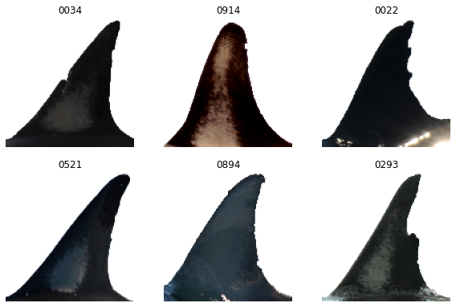

```python
import matplotlib.pyplot as plt

class_names = train_dataset.class_names
plt.figure(figsize=(10, 10))
for images, labels in train_dataset.take(1):
  for i in range(6):
    ax = plt.subplot(3, 3, i + 1)
    plt.imshow(images[i].numpy().astype("uint8"))
    plt.title(class_names[labels[i]])
    plt.axis("off")
```

```python
train_dataset = train_dataset.cache().shuffle(1000).prefetch(buffer_size=tf.data.AUTOTUNE)
val_dataset = val_dataset.cache().prefetch(buffer_size=tf.data.AUTOTUNE)
full_dataset = full_dataset.cache().shuffle(1000).prefetch(buffer_size=tf.data.AUTOTUNE)
test_dataset = test_dataset.cache().shuffle(1000).prefetch(buffer_size=tf.data.AUTOTUNE)
```

We first perform online learning with semi-hard loss - the best results according to the FaceNet paper. Subsequently, we may perform online learning with hard loss

```python
epochs=50
history = model.fit(
  train_dataset,
  validation_data = val_dataset,
  epochs = epochs,
  callbacks = [
    #tf.keras.callbacks.EarlyStopping(monitor='val_loss', mode='min', restore_best_weights = True, patience = 10),
    tf.keras.callbacks.ModelCheckpoint(f"{CHECKPOINT_DIR}/training_semi_simple_aug", monitor= 'val_loss', save_best_only = True, mode = "min", save_weights_only = True)
  ]
)

# model.save_weights(f"{CHECKPOINT_DIR}/training_semi")
```

We visualise the training results.

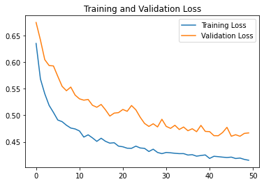

```python
def plot_loss(epochs, history):
  loss = history.history['loss']
  val_loss = history.history['val_loss']
  epochs_range = range(epochs)
  plt.plot(epochs_range, loss, label='Training Loss')
  plt.plot(epochs_range, val_loss, label='Validation Loss')
  plt.legend(loc='upper right')
  plt.title('Training and Validation Loss')
  plt.show()

plot_loss(epochs, history)
```

Better. Preprocessing makes a difference. We'll try again with hard loss.

```python
model.compile(
  optimizer=tf.keras.optimizers.Adam(0.001),
  loss=tfa.losses.TripletHardLoss()
)

epochs=50
history = model.fit(
  train_dataset,
  validation_data = val_dataset,
  epochs = epochs,
  callbacks = [
    #tf.keras.callbacks.EarlyStopping(monitor='val_loss', mode='min', restore_best_weights = True, patience = 10),
    tf.keras.callbacks.ModelCheckpoint(f"{CHECKPOINT_DIR}/training_semi_simple_aug", monitor= 'val_loss', save_best_only = True, mode = "min", save_weights_only = True)
  ]
)
```

[figure not shown]

```python
plot_loss(epochs, history)
```

Not so bad, but the results seem to plateau quickly. We should initially stick with semi-hard loss.

Increasing the batch size might make a difference

```python
def build_data(batch_size):
  train_dataset = tf.keras.preprocessing.image_dataset_from_directory(
      data_dir,
      labels="inferred",
      label_mode="int",
      class_names=None,
      color_mode="rgba",
      batch_size=batch_size,
      image_size=(DIM, DIM),
      shuffle=True,
      seed=SEED,
      validation_split=VAL_PROP,
      subset="training",
      interpolation="bilinear",
      follow_links=False,
  )

  val_dataset = tf.keras.preprocessing.image_dataset_from_directory(
      data_dir,
      labels="inferred",
      label_mode="int",
      class_names=None,
      color_mode="rgba",
      batch_size=batch_size,
      image_size=(DIM, DIM),
      shuffle=True,
      seed=SEED,
      validation_split=VAL_PROP,
      subset="validation",
      follow_links=False,
  )

  full_dataset = tf.keras.preprocessing.image_dataset_from_directory(
      data_dir,
      labels="inferred",
      label_mode="int",
      color_mode="rgba",
      # batch_size=batch_size,
      image_size=(DIM, DIM),
      shuffle=True,
      seed=SEED,
  )

  test_dataset = tf.keras.preprocessing.image_dataset_from_directory(
      test_dir,
      labels="inferred",
      label_mode="int",
      color_mode="rgba",
      # batch_size=batch_size,
      image_size=(DIM, DIM),
      shuffle=True,
      seed=SEED,
  )

  train_dataset = train_dataset.cache().shuffle(1000).prefetch(buffer_size=tf.data.AUTOTUNE)
  val_dataset = val_dataset.cache().prefetch(buffer_size=tf.data.AUTOTUNE)
  full_dataset = full_dataset.cache().shuffle(1000).prefetch(buffer_size=tf.data.AUTOTUNE)
  test_dataset = test_dataset.cache().shuffle(1000).prefetch(buffer_size=tf.data.AUTOTUNE)

  return train_dataset, val_dataset, full_dataset, test_dataset
train_dataset, val_dataset, full_dataset, test_dataset = build_data(256)
```

```
Found 3364 files belonging to 186 classes.
Using 2860 files for training.
Found 3364 files belonging to 186 classes.
Using 504 files for validation.
Found 3364 files belonging to 186 classes.
Found 382 files belonging to 186 classes.
```

```python
epochs=50
history = model.fit(
  train_dataset,
  validation_data = val_dataset,
  epochs = epochs,
  callbacks = [
    #tf.keras.callbacks.EarlyStopping(monitor='val_loss', mode='min', restore_best_weights = True, patience = 10),
    tf.keras.callbacks.ModelCheckpoint(f"{CHECKPOINT_DIR}/training_semi_simple_aug", monitor= 'val_loss', save_best_only = True, mode = "min", save_weights_only = True)
  ]
)
```

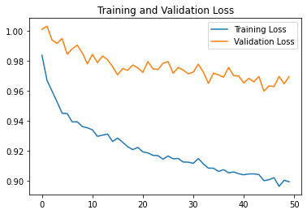

```python
plot_loss(epochs, history)
```

We'll switch back to semi-hard loss

```python
model.compile(
  optimizer=tf.keras.optimizers.Adam(0.001),
  loss=tfa.losses.TripletSemiHardLoss()
)

epochs=50
history = model.fit(
  train_dataset,
  validation_data = val_dataset,
  epochs = epochs,
  callbacks = [
    #tf.keras.callbacks.EarlyStopping(monitor='val_loss', mode='min', restore_best_weights = True, patience = 10),
    tf.keras.callbacks.ModelCheckpoint(f"{CHECKPOINT_DIR}/training_semi_simple_aug", monitor= 'val_loss', save_best_only = True, mode = "min", save_weights_only = True)
  ]
)
```

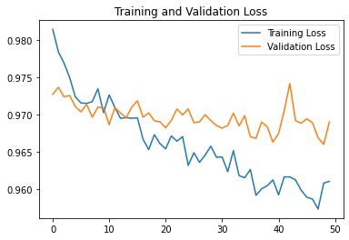

```python
plot_loss(epochs, history)
```

So, a smaller batch size might be preferable to start with

```python
train_dataset, val_dataset, full_dataset, test_dataset = build_data(64)
epochs=50
history = model.fit(
  train_dataset,
  validation_data = val_dataset,
  epochs = epochs,
  callbacks = [
    #tf.keras.callbacks.EarlyStopping(monitor='val_loss', mode='min', restore_best_weights = True, patience = 10),
    tf.keras.callbacks.ModelCheckpoint(f"{CHECKPOINT_DIR}/training_semi_simple_aug", monitor= 'val_loss', save_best_only = True, mode = "min", save_weights_only = True)
  ]
)
```

```
Found 3364 files belonging to 186 classes.
Using 2860 files for training.
Found 3364 files belonging to 186 classes.
Using 504 files for validation.
Found 3364 files belonging to 186 classes.
Found 382 files belonging to 186 classes.
```

So, we will generate the embeddings, visualise them, and use a KNN classifier.

```python
img = tf.keras.preprocessing.image.load_img(
    "/proj/MyDrive/158780_Project_Dolphin_Computer_Vision/images/final_to_match/HG_160510_040_DE_N1.JPG",
    target_size=(DIM, DIM, THIRD_DIM),
    color_mode="rgba"
)
img_array = tf.keras.preprocessing.image.img_to_array(img)
img_array = tf.expand_dims(img_array, 0)

predictions = model.predict(img_array)
score = tf.nn.softmax(predictions[0])

print(
    "Prediction: Class {} with {:.2f}% confidence."
    .format(class_names[np.argmax(score)], 100 * np.max(score))
)
```

```
Prediction: Class 0418 with 0.46% confidence.
```

```python
train_embeddings = model.predict(full_dataset)
test_embeddings = model.predict(test_dataset)
train_embeddings.shape
```

```
(3364, 256)
```

We retrieve the class labels.

```python
y_train = np.concatenate([y for x, y in full_dataset], axis=0)
y_test = np.concatenate([y for x, y in test_dataset], axis=0)
y_train[0:100]
```

```
array([106,  74,  81,   4,  15,   1, 140, 110,   8, 152, 128, 140, 125,
       107,  70, 121, 138,  30, 128,   4, 167, 168, 101,  71,  85,  59,
        99,  46, 123,  67,  46,  52,  81, 131, 172, 153,  42,  53, 120,
       145,  13,  29,  84, 107,  60,  21, 145, 152, 138,   3, 158, 107,
       183,  56, 119, 156,  48,  49,  11,  43, 131,   9,  16,  60,  60,
        77,  56, 105, 145, 141, 164,  71,  82,  43,  82, 170,  20, 169,
       119,  54, 154,   2, 142, 162,  62,   4,   1,  43, 179,  17,  10,
        43,  79, 173,  44, 142,  74, 173, 167, 115], dtype=int32)
```

Next, we plot the results.

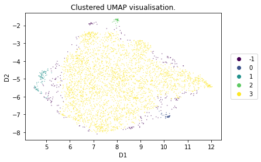

```python
mapper=umap.UMAP( n_neighbors = 100, min_dist= 0.1).fit(train_embeddings, y_train)
cluster = hdbscan.HDBSCAN(
    algorithm ='best',
    approx_min_span_tree = True,
    gen_min_span_tree = False,
    leaf_size = 40,
    metric='euclidean',
    min_cluster_size = 25,
    min_samples = 25,
    p = None
).fit(mapper.embedding_)

plt.title("Clustered UMAP visualisation.")
scatter = plt.scatter(
    mapper.embedding_[:, 0],
    mapper.embedding_[:, 1],
    c = cluster.labels_,
    s = 0.1,
)

plt.legend(
  handles = scatter.legend_elements()[0],
  labels = pd.Series(cluster.labels_.tolist()).astype("string").sort_values().unique(),
  loc="right",
  bbox_to_anchor=(1.2, 0.5)
)
plt.xlabel("D1")
plt.ylabel("D2")
plt.show();
```

Not so good. The clusters are not well formed.

```python
knn=KNeighborsClassifier(100)
knn.fit(mapper.embedding_, y_train)
```

```
KNeighborsClassifier(algorithm='auto', leaf_size=30, metric='minkowski',
                     metric_params=None, n_jobs=None, n_neighbors=100, p=2,
                     weights='uniform')
```

```python
knn.score(mapper.transform(test_embeddings), y_test)
```

```
0.01832460732984293
```

The KNN classifier has not done a good job. But data augmentation makes a difference.

In part 3, we combine data augmentation with transfer learning on a ResNet50 model. We stick with semi-hard loss initially.

```python
%%shell
jupyter nbconvert --to html /content/4_2_triplet_loss_dolphin_simple_architecture_aug.ipynb
```

[output not shown]

[output cut: 75 more lines]

[output not shown]

[output not shown]